# Milestone Report - Analysis of Coursera-Swiftkey Dataset

B Porter

November 27, 2016

## Summary

This milestone report will detail the exploratory data analysis of the text data set provided for the capstone project ([Coursera-SwiftKey dataset](https://d396qusza40orc.cloudfront.net/dsscapstone/dataset/Coursera-SwiftKey.zip)). The dataset contains text samples in multiple languages. The focus of this project is on the english text samples. The text samples are sampled from three different sources: twitter, blogs, and news. The goal is to use these text observations to build a text prediction model. This report explains the exploratory data anaylsis performed and the plans for the predictive n-gram model.

## Full Swiftkey Dataset Analysis

The first step is to download and unzip the data.

```r
blog_file_path <- './final/en_US/en_US.blogs.txt'
if (!file.exists(blog_file_path)){
    download.file("https://d396qusza40orc.cloudfront.net/dsscapstone/dataset/Coursera-SwiftKey.zip", "swiftkey_dataset.zip", "auto")
    unzip('swiftkey_dataset.zip')
}
```

The three files that make up the corpus are: en_US.blogs.txt, en_US.news.txt, and en_US.twitter.txt. Before we subsample the dataset let’s see what the raw data looks like.

```r
corpus <- VCorpus(DirSource('./final/en_US', encoding = "UTF-8"), readerControl = list(reader=readPlain, language="en_US"))
inspect(corpus)
```

```
## <<VCorpus>>
## Metadata:  corpus specific: 0, document level (indexed): 0
## Content:  documents: 3
##
## [[1]]
## <<PlainTextDocument>>
## Metadata:  7
## Content:  chars: 206824505
##
## [[2]]
## <<PlainTextDocument>>
## Metadata:  7
## Content:  chars: 15639408
##
## [[3]]
## <<PlainTextDocument>>
## Metadata:  7
## Content:  chars: 162096031
```

The first thing to look at after loading the data is to see how many lines of text we have and what is the approximate unfiltered word count. The following gives the line count of each document. Then we sum the length of the word lists of each line in the documents to get the word count.

```r
build.count.df <- function(in.corpus, doc.count){
  df.counts <- data.frame(document=character(), line.count=integer(), word.count=integer(), stringsAsFactors = F)
  for(i in 1:doc.count){
    split <- strsplit(as.character(corpus[[i]]), " ")
    split.line.count <- length(split)
    split.word.count <- sum(unlist(lapply(split, length)))
    split.df <- data.frame(document=meta(corpus[[i]])$id, line.count=split.line.count, word.count=split.word.count)
    df.counts <- rbind(df.counts, split.df)
  }
  df.counts
}
corpus.size.df <- build.count.df(corpus, 3)
rm(corpus);d<-gc()
head(corpus.size.df)
```

```
##            document line.count word.count
## 1   en_US.blogs.txt     899288   37334131
## 2    en_US.news.txt      77259    2643969
## 3 en_US.twitter.txt    2360148   30373543
```

Now we can take the summary data and display it in a plot. This shows the distribution of words and lines of text per document in the corpus.

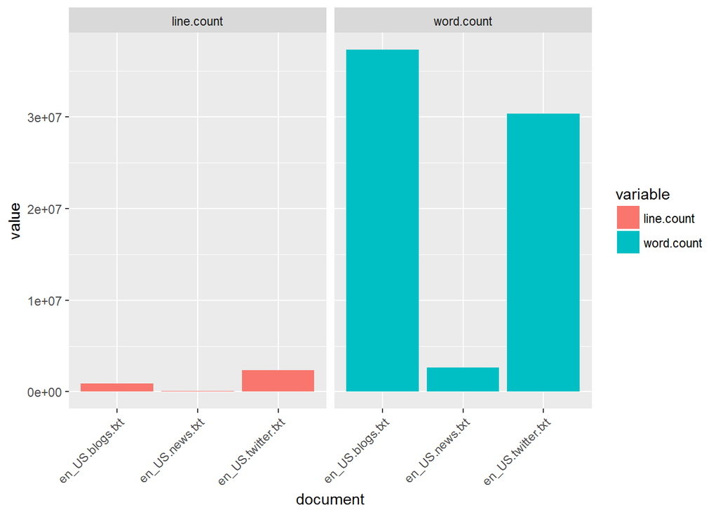

```r
df.long <- melt(corpus.size.df, id.vars=c("document"))
ggplot(data=df.long, aes(x=document, y=value, fill=variable)) +
  geom_bar(stat='identity') + facet_grid(.~variable) +
  theme(axis.text.x=element_text(angle = 45, hjust = 1))
```

## Subset the full dataset

From the initial dataset analysis we see that each text data file is very big. For a further analysis we should generate a smaller sample of the full dataset. With the smaller dataset we can hope to extrapolate information about the full dataset. Such as how we will need to clean the data and what are the frequent words, and n-grames in the data.

```r
set.seed(123321)
sample.document <- function(file.path, line.count, out.path, percent=0.01){
  sample.doc = sample_lines(file.path, n=line.count*percent, nlines=line.count)
  out.conn <- file(out.path, "w")
  writeLines(sample.doc, con = out.conn, sep="")
  close(out.conn)
}
corpus.size.df$document <- as.character(corpus.size.df$document)
corpus.size.df$sample.document <- c("blogs.sample.txt", "news.sample.txt", "twitter.sample.txt")
sample.dir <- 'final/en_US/sample/'
data.dir <- 'final/en_US/'
dir.create(sample.dir)
for(i in 1:3){
  file.path <- paste(data.dir,corpus.size.df$document[i], sep="")
  out.path <- paste(sample.dir, corpus.size.df$sample.document[i], sep="")
  sample.document(file.path, corpus.size.df$line.count[i], out.path)
}
sample.corpus <- VCorpus(DirSource(sample.dir), readerControl = list(language = "en_US"))
```

## Clean the data

In order to use the dataset to accurately predict text we need to first clean the dataset. We have data from different sources and those sources have some terms that do not contribute to an accurate text predictor. For example any twitter hashtag terms are likely not valuable to predict for a user. You also cannot assume that hashtag terms will be sparse. They may be quite common and make text prediction waited towards producing hashtag terms. We also want to remove any non-english terms for this project because we are trying to produce an english text prediction model.

```r
#function to remove non-english words
removeNonEnglish <- function(x){
  #replace non-english words with !NonEng!
  x <- iconv(x, 'latin1', 'ASCII', '!NonEng!')
  #use gsub to replace any word containing !NonEng! with ''
  gsub(pattern = '\\S*!NonEng!\\S*', replacement = '',x = x)
}

sample.corpus <- tm_map(sample.corpus, content_transformer(removeNonEnglish))
sample.corpus <- tm_map(sample.corpus, content_transformer(gsub), pattern="#\\S*", replacement="")
sample.corpus <- tm_map(sample.corpus, content_transformer(gsub), pattern="@\\S*", replacement="")
sample.corpus <- tm_map(sample.corpus, content_transformer(gsub), pattern="/|@|\\|", replacement="")
sample.corpus <- tm_map(sample.corpus, content_transformer(gsub), pattern="\\S*.com\\S*", replacement="")
sample.corpus <- tm_map(sample.corpus, content_transformer(gsub), pattern="\\S*.net\\S*", replacement="")
sample.corpus <- tm_map(sample.corpus, content_transformer(gsub), pattern="\\S*.org\\S*", replacement="")
sample.corpus <- tm_map(sample.corpus, content_transformer(tolower))
sample.corpus <- tm_map(sample.corpus, content_transformer(gsub), pattern="rt|via", replacement="")
sample.corpus <- tm_map(sample.corpus, removeNumbers)
sample.corpus <- tm_map(sample.corpus, removePunctuation)
```

Part of the data cleaning process is removing words that would be offensive to suggest in our predictive text model. For this step I found a word list from a website called bannedwordlist.com. The following script downloads this file if it doesn’t already exist and uses it to remove those bad words from the corpus.

```r
if (!file.exists("bad_words.csv")) {
  download.file("http://www.bannedwordlist.com/lists/swearWords.csv", "bad_words.csv", "auto")
}
bad.words <- read.csv("bad_words.csv")
sample.corpus <- tm_map(sample.corpus, removeWords, bad.words)
```

The final clean up steps would be to remove stopwords and strip whitespace for the document. For our initial analysis we will not remove the english stop words because they maybe valuable to our prediction model. We may want to predict these stop words and they are very common in normal conversation.

```r
sample.corpus <- tm_map(sample.corpus, stripWhitespace)
#sample.corpus <- tm_map(sample.corpus, removeWords, stopwords("english"))
```

## Understanding the data

In order to better understand the dataset it is important to look at frequent terms and ngrams. To start we will create a document term matrix of the sample corpus. The document term matrix is useful in understanding the word frequencies in the corpus and what the distribution of frequencies are. The following code block generates the first document term matrix and a function for generating a frequency data frame.

```r
#Generate the DTM
dtm <- DocumentTermMatrix(sample.corpus)
dtm <- removeSparseTerms(dtm, 0.9)

# Function to generate frequencies
# Input: DTM - document term matrix
# Input: top.num.count - the number of terms to return sorted by most frequent
# Output: Dataframe with term and frequency members.
generate.frequencies <- function(dtm, top.num.count=-1){
  freq.terms <- colSums(as.matrix(dtm))
  if (top.num.count > 0){
    ord <- order(freq.terms)
    freq.terms <- freq.terms[tail(ord, top.num.count)]
  }
  freq.terms.df <- data.frame(term=names(freq.terms), frequency=freq.terms)
  freq.terms.df
}
```

## Most frequent terms plots

After generating the DTM we can create some basic plots to better understand the data. The first three plots show the top ten most common terms per document. You can see from these plots that many of the most frequent words are english stop words. We could filter these out but for the initial exploration I chose to keep them in.

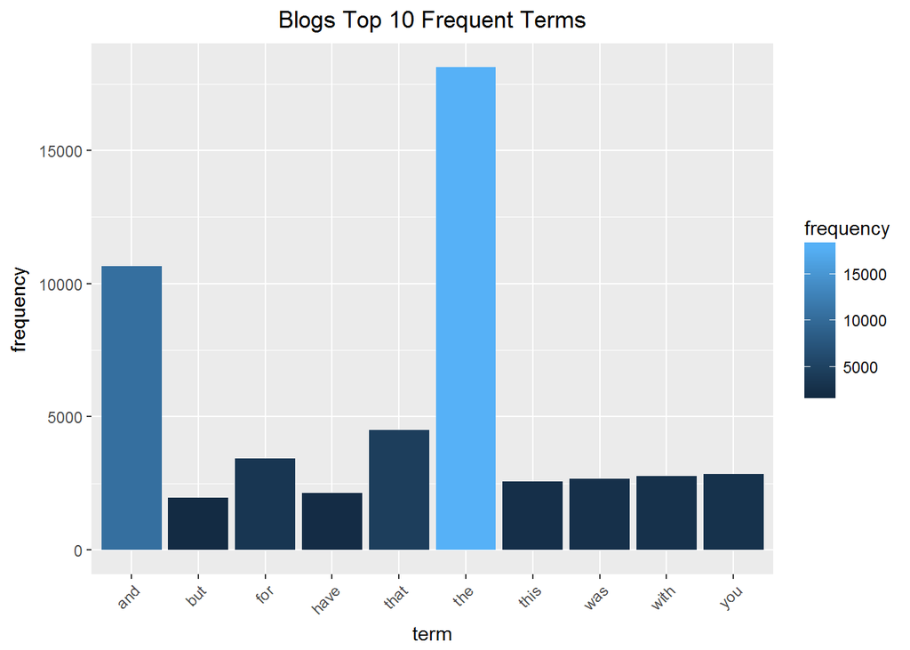

```r
list.freqs <- lapply(dtm$dimnames$Docs, function(i) generate.frequencies(dtm[dtm$dimnames$Docs == i,], 10))

create.plot <- function(freqs, title='Frequency Plot'){
  freq.plot <- ggplot(freqs, aes(term, frequency, fill=frequency))
  freq.plot <- freq.plot + geom_bar(stat='identity')
  freq.plot <- freq.plot + theme(axis.text.x=element_text(angle = 45, hjust = 1),
                                 plot.title = element_text(hjust = 0.5))
  freq.plot <- freq.plot + ggtitle(title)
  freq.plot
}
p1 <- create.plot(list.freqs[[1]], "Blogs Top 10 Frequent Terms")
p1
```

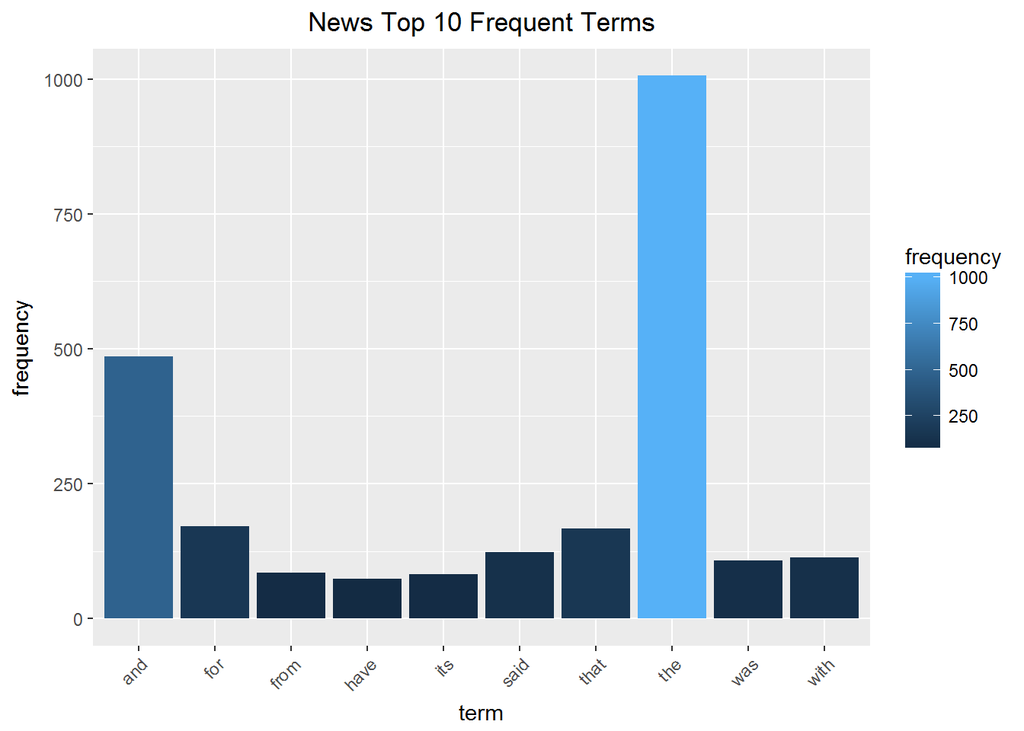

```r
p2 <- create.plot(list.freqs[[2]], "News Top 10 Frequent Terms")
p2
```

[figure not shown]

```r
p3 <- create.plot(list.freqs[[3]], "News Top 10 Frequent Terms")
p3
```

The next plot shows a term frequency histogram. This shows that most terms are seen this sample corpus less than 25 times. The terms that are seen most frequent represent the smallest amount of unique terms in the dataset.

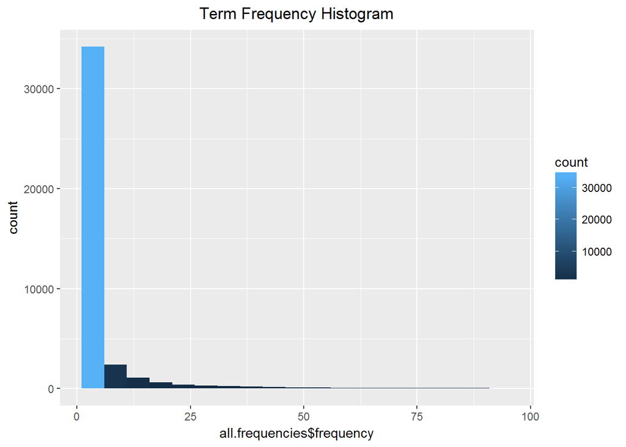

```r
all.frequencies <- generate.frequencies(dtm)
p5 <- ggplot(data=all.frequencies, aes(all.frequencies$frequency)) + geom_histogram(breaks=seq(1,100, by=5), aes(fill=..count..))
p5 <- p5 + ggtitle("Term Frequency Histogram") + theme(plot.title = element_text(hjust = 0.5))
p5
```

## Dictionary coverage

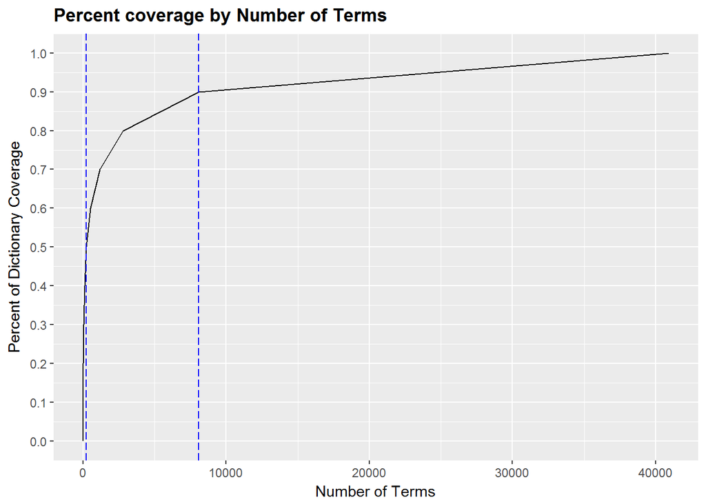

```r
#function to count the number of unique words needed to reach the
count.unique.words <- function(freq.vec, coverage.percent){
  count = 0
  total.words = sum(freq.vec)
  while(sum(freq.vec[1:count])/total.words < coverage.percent) count=count + 1
  count
}
# Generate the frequency of one-gram words (from DocumentTermMatrix)
freq <- colSums(as.matrix(dtm))
freq <- sort(freq, decreasing = TRUE)

coverage <- data.frame(rate=seq(0, 1, 0.1), word.count=sapply(seq(0, 1, 0.1), function(x) count.unique.words(freq, x)))
ggplot(coverage, aes(word.count, rate)) +
  geom_line() +
  scale_y_continuous(breaks = seq(0, 1, 0.1)) +
  geom_vline(xintercept=coverage[coverage$rate ==0.5, "word.count"], col = 'blue', linetype = 5) +
  geom_vline(xintercept=coverage[coverage$rate ==0.9, "word.count"], col = 'blue', linetype = 'longdash') +
  ggtitle('Percent coverage by Number of Terms') +
  theme(plot.title = element_text(lineheight = .8, face = 'bold')) +
  labs(x = 'Number of Terms', y = 'Percent of Dictionary Coverage')
```

## N-Grams

The next thing to do in order to understand the dataset is to explore the bigrams and trigrams. To do this we use the RWeka NGramTokenizer. After creating the DTM using this tokenizer we plot the top 10 most common bigram and trigram terms. These plots show that most common phrases contain common stop words. The n-grams will be integral to building a model. They will be used to build a simple model to predict the next term by finding the maximum likelihood estimation of the next term given the history, or terms that have come before it.

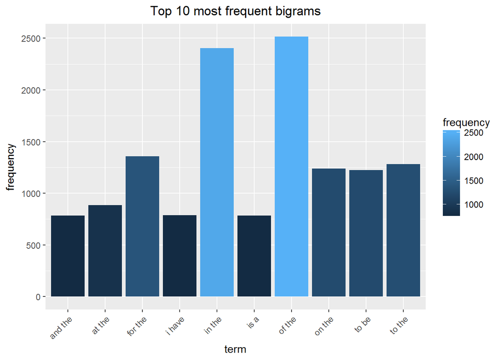

```r
find.n.gram <- function(corpus, ngram=2){

  # Create Term Document Matrix with tokenization
  options(mc.cores=1)
  gramTokenizer <- function(x) NGramTokenizer(x,Weka_control(min=ngram,max=ngram))
  dtm <- DocumentTermMatrix(corpus, control = list(tokenize = gramTokenizer))
  dtm
}

# 2-gram words
bigram.dtm <-  find.n.gram(sample.corpus)
bigram.freq <- generate.frequencies(bigram.dtm, 10)
bp1 <- create.plot(bigram.freq, "Top 10 most frequent bigrams")
bp1
```

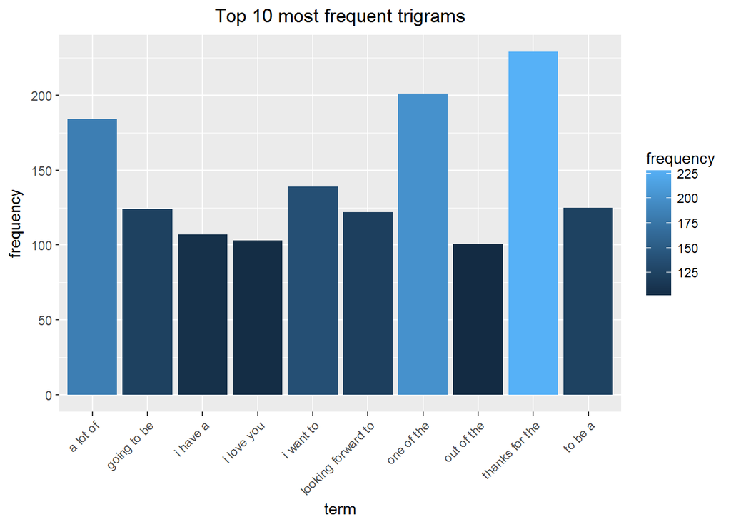

```r
trigram.dtm <-  find.n.gram(sample.corpus, 3)
trigram.freq <- generate.frequencies(trigram.dtm, 10)
bp2 <- create.plot(trigram.freq, "Top 10 most frequent trigrams")
bp2
```

## Model and Prediction

After doing this exploratory analysis I have a general idea of how to build first an n-gram model. I will start by building a basic n-gram model and use the generated unigram, bigram and trigram from a sample of the corpus. This will be the initial model and I will be the shiny app around it. Once that is done I will come back and try to improve the model coverage and use backoff models to estimate the probability of unobserved n-grams as well as smooth the probabilities for the next term predicted.